# Predict Podcast Listening Time

```python
import numpy as np #for math
import pandas as pd #for data
import seaborn as sb #for charts
import matplotlib.pyplot as plt #for charts
%matplotlib inline
# show plots in Jupyter Notebooks directly under the code cell
```

## 1. Exploratory Data Analysis (EDA)

```python
data=pd.read_csv("train.csv")
```

```python
data.head(5)
```

|  | id | Podcast_Name | Episode_Title | Episode_Length_minutes | Genre | Host_Popularity_percentage | Publication_Day | Publication_Time | Guest_Popularity_percentage | Number_of_Ads | Episode_Sentiment | Listening_Time_minutes |
| --- | --- | --- | --- | --- | --- | --- | --- | --- | --- | --- | --- | --- |
| 0 | 0 | Mystery Matters | Episode 98 | NaN | True Crime | 74.81 | Thursday | Night | NaN | 0.0 | Positive | 31.41998 |
| 1 | 1 | Joke Junction | Episode 26 | 119.80 | Comedy | 66.95 | Saturday | Afternoon | 75.95 | 2.0 | Negative | 88.01241 |
| 2 | 2 | Study Sessions | Episode 16 | 73.90 | Education | 69.97 | Tuesday | Evening | 8.97 | 0.0 | Negative | 44.92531 |
| 3 | 3 | Digital Digest | Episode 45 | 67.17 | Technology | 57.22 | Monday | Morning | 78.70 | 2.0 | Positive | 46.27824 |
| 4 | 4 | Mind & Body | Episode 86 | 110.51 | Health | 80.07 | Monday | Afternoon | 58.68 | 3.0 | Neutral | 75.61031 |

**- Since ID is just a unique identifier to each record and does not carry meaningful information, I choose to drop it.**

```python
data=data.drop('id',axis=1) #axis=1 specifies to drop column not row
data.head(5)
```

|  | Podcast_Name | Episode_Title | Episode_Length_minutes | Genre | Host_Popularity_percentage | Publication_Day | Publication_Time | Guest_Popularity_percentage | Number_of_Ads | Episode_Sentiment | Listening_Time_minutes |
| --- | --- | --- | --- | --- | --- | --- | --- | --- | --- | --- | --- |
| 0 | Mystery Matters | Episode 98 | NaN | True Crime | 74.81 | Thursday | Night | NaN | 0.0 | Positive | 31.41998 |
| 1 | Joke Junction | Episode 26 | 119.80 | Comedy | 66.95 | Saturday | Afternoon | 75.95 | 2.0 | Negative | 88.01241 |
| 2 | Study Sessions | Episode 16 | 73.90 | Education | 69.97 | Tuesday | Evening | 8.97 | 0.0 | Negative | 44.92531 |
| 3 | Digital Digest | Episode 45 | 67.17 | Technology | 57.22 | Monday | Morning | 78.70 | 2.0 | Positive | 46.27824 |
| 4 | Mind & Body | Episode 86 | 110.51 | Health | 80.07 | Monday | Afternoon | 58.68 | 3.0 | Neutral | 75.61031 |

```python
print("\033[1m- The data has",data.shape[0], "observations and",data.shape[1],"variables.")
```

```
- The data has 750000 observations and 11 variables.
```

```python
# Data.info
## Create a dictionary with column information
info_dict = {
    'Column':data.columns,
    'Null count': [data[column].isnull().sum() for column in data.columns],
    'Type': [data[column].dtype for column in data.columns]
}

## Convert the dictionary to a DataFrame
info_data = pd.DataFrame(info_dict)
info_data
```

|  | Column | Null count | Type |
| --- | --- | --- | --- |
| 0 | Podcast_Name | 0 | object |
| 1 | Episode_Title | 0 | object |
| 2 | Episode_Length_minutes | 87093 | float64 |
| 3 | Genre | 0 | object |
| 4 | Host_Popularity_percentage | 0 | float64 |
| 5 | Publication_Day | 0 | object |
| 6 | Publication_Time | 0 | object |
| 7 | Guest_Popularity_percentage | 146030 | float64 |
| 8 | Number_of_Ads | 1 | float64 |
| 9 | Episode_Sentiment | 0 | object |
| 10 | Listening_Time_minutes | 0 | float64 |

```python
print("\033[1m- The data has",(info_data['Type']=='object').sum(), "categorical variables and",(info_data['Type']=='float64').sum(),"numerical variables.")
```

```
- The data has 6 categorical variables and 5 numerical variables.
```

**- Although Episode_Title contains string values (Episode 1, Episode 2, ... Episode 100), it presents ordinal, numeric information in disgue. Hence i will conver it to an numeric (ordinal) variable.**

**- Numerical variables:**

- Episode_Title
- Episode_Length_minutes
- Host_Popularity_percentage
- Guest_Popularity_percentage
- Number_of_Ads
- Listening_Time_minitues

**- Categorical variables:**

- Podcast_Name
- Genre
- Publication_Day
- Publication_Time
- Episode_Sentiment

**- The Data contains a lot of null values:**

- *Episode_Length_minutes* has 87,093 null values.
- *Guest_Popularity_percentage* has 146,030 null values.
- *Number_of_Ads* has 1 null value.

**We will analyze each variable further to consider how to deal with their null values later.**

#### 1.1. Numerical Variables

*(Episode_Title; Episode_Length_minutes; Host_Popularity_percentage; Guest_Popularity_percentage; Number_of_Ads; Listening_Time_minutes)*

```python
data['Episode_Number']=data['Episode_Title'].str.extract(r'(\d+)').astype(int)
data=data.drop('Episode_Title',axis=1) #axis=1 specifies to drop column not row
```

```python
data.describe()
```

|  | Episode_Length_minutes | Host_Popularity_percentage | Guest_Popularity_percentage | Number_of_Ads | Listening_Time_minutes | Episode_Number |
| --- | --- | --- | --- | --- | --- | --- |
| count | 662907.000000 | 750000.000000 | 603970.000000 | 749999.000000 | 750000.000000 | 750000.000000 |
| mean | 64.504738 | 59.859901 | 52.236449 | 1.348855 | 45.437406 | 51.445811 |
| std | 32.969603 | 22.873098 | 28.451241 | 1.151130 | 27.138306 | 28.085623 |
| min | 0.000000 | 1.300000 | 0.000000 | 0.000000 | 0.000000 | 1.000000 |
| 25% | 35.730000 | 39.410000 | 28.380000 | 0.000000 | 23.178350 | 28.000000 |
| 50% | 63.840000 | 60.050000 | 53.580000 | 1.000000 | 43.379460 | 52.000000 |
| 75% | 94.070000 | 79.530000 | 76.600000 | 2.000000 | 64.811580 | 75.000000 |
| max | 325.240000 | 119.460000 | 119.910000 | 103.910000 | 119.970000 | 100.000000 |

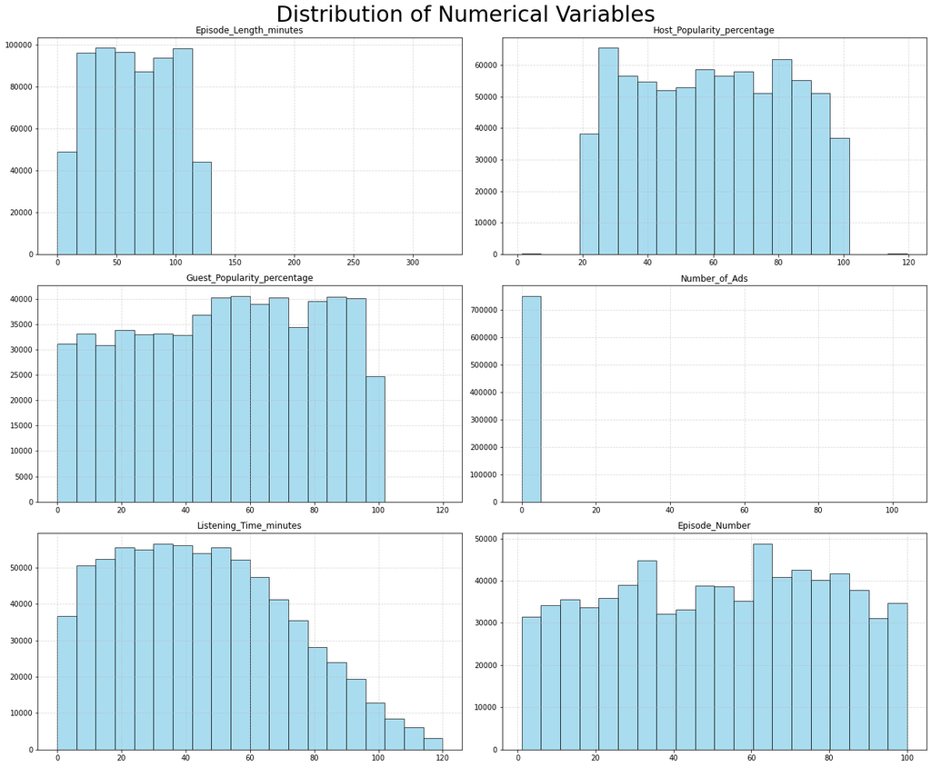

```python
num_var=data.select_dtypes(include=['float64','int32']) #select numerical variables

#Plot histogram
hist=num_var.hist(bins=20,color='skyblue', edgecolor='black',alpha=0.7, figsize=(18,15)) #devide data into 10 intervals/bins, Color, edge color,transparency 70%
for hist in hist.flatten(): #Flatten in case it's a 2D array of axes
    hist.grid(True,linestyle='--',alpha=0.5) #add grid line to each subplot

plt.suptitle('Distribution of Numerical Variables', fontsize=30) #Add super title/overall title

plt.tight_layout() #Automatically adjusts the spacing in the figure so that labels, titles, and ticks don’t get cut off or overlap.



plt.show()
```

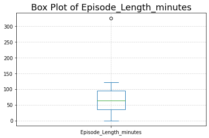

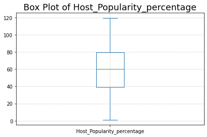

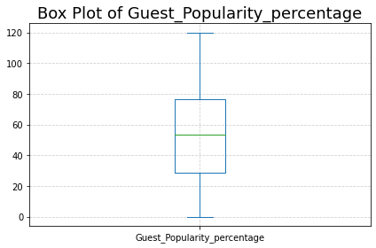

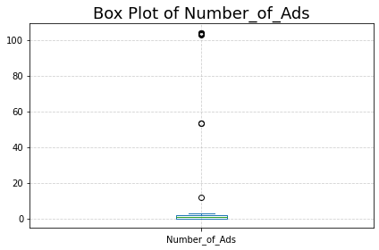

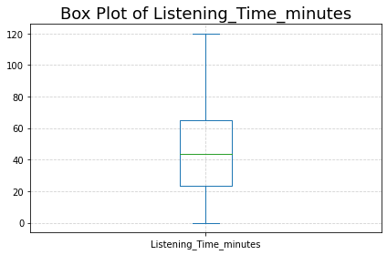

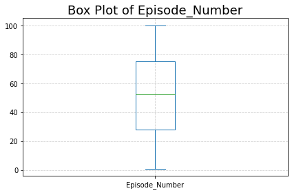

```python
for column in num_var.columns:
    plt.figure(figsize=(6,4))
    num_var[column].plot(kind='box')
    plt.title(f'Box Plot of {column}',fontsize=18)
    plt.grid(True,linestyle='--',alpha=0.6)
    plt.tight_layout()

plt.show()
```

**- Host Popularity Percentage:** almost uniform; most are range from 20% to 100%

**- Guest Popularity Percentage:** almost uniform; range from 0 to 100%; there are some that above 100%.

**- Number of Ads:** This variable is strongly right-skewed. After checking the data, I found 9 records with extreme values (12, 53.37, 103.91, 103, 53.42, 103.75, 103.25, 103.25, 103.88). These might be outliers or data entry errors, and should either be replaced with the variable’s mode or removed. Most of the other values are between 0 and 3, so it may make more sense to treat this variable as categorical instead of numeric.

**- Listening Time Minutes:** a right-skewed distribution with a high concentration between 20 and 40 minutes, but includes episodes with significantly longer durations. To improve prediction accuracy, consider normalizing this dependent variable or employing models robust to non-normal distributions.

**- Episode Number:** almost uniform; data is range from 1 to 100

```python
# Replace Number_of_Ads outliers with its mode
NoA_mode=data['Number_of_Ads'].mode()[0]
data['Number_of_Ads']=data['Number_of_Ads'].apply(lambda x: NoA_mode if x > 3 else x)
```

```python
#Convert Number_of_Ads to categorical type
data['Number_of_Ads']=data['Number_of_Ads'].astype('object')
```

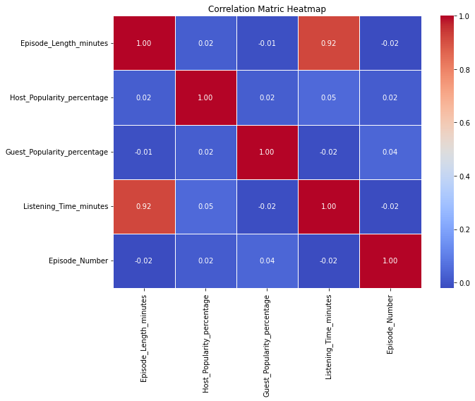

```python
# Calculate the correlation matrix
corr_matrix = data.corr(method='pearson')
plt.figure(figsize=(10,8))
sb.heatmap(corr_matrix,annot=True,cmap='coolwarm',fmt=".2f",linewidths=.5)
plt.title('Correlation Matric Heatmap')
plt.tight_layout()
plt.show()
```

**- Episode_Length_minutes shows a strong and reasonable correlation with Listening_Time_minutes.**

**- Other variables do not appear to be highly correlated with Listening_Time_minutes or with each other.**

#### 1.2. Categorical Variables

*Podcast_Name; Genre; Publication_Day; Publication_Time; Episode_Sentiment*

```python
cat_var=data.select_dtypes(include='object')
cat_var=cat_var.drop('Podcast_Name',axis=1)
```

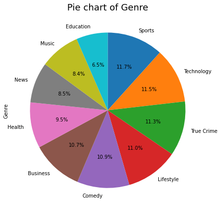

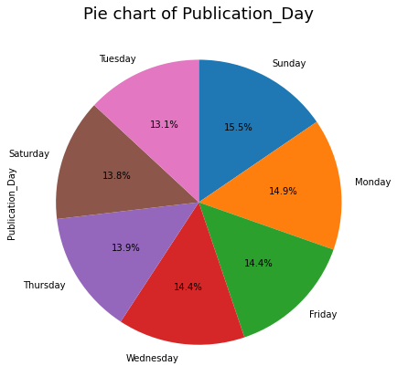

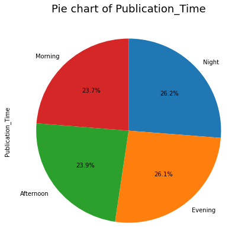

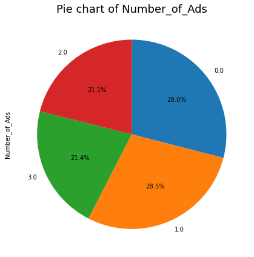

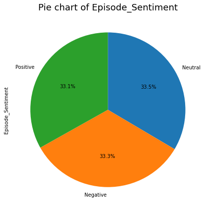

```python
for cat_column in cat_var.columns:
    plt.figure(figsize=(10,6))
    cat_var[cat_column].value_counts().plot(
        kind='pie',
        autopct='%1.1f%%', #Show 1 decimal place percentage
        startangle=90, #rotate for consistent layout
        counterclock=False #clockwise direction
    )
    plt.title(f'Pie chart of {cat_column}',fontsize=18)
    plt.grid(True,linestyle='--',alpha=0.6)
    plt.tight_layout()

plt.show()
```

**- Based on information provided in the the charts above, the categorical variables appear to have a fairly balanced distribution. This is benefical for building the model later, as it reduces the risk of the model being heavily biased toward any single class**

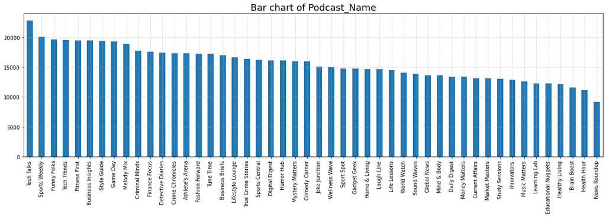

```python
plt.figure(figsize=(16.5,6))
data['Podcast_Name'].value_counts().plot(kind='bar')
plt.title('Bar chart of Podcast_Name',fontsize=18)
plt.grid(True,linestyle='--',alpha=0.6)
plt.tight_layout()

plt.show()
```

## 2. Cleanning Data

(Replace outliers, missing values of each variable with its mean)

```python
new_data=data.copy()
```

###### Outliers

**- Episode_Length_minutes: Upon review, this variable appears to have two outliers.**

- The first is 325.24, which is significantly larger than the other values. I will replace it with the variable's mean.
- The second is 0. Since Episode_Length_minutes is a float type and a podcast length of 0 minutes is not reasonable, I will also replace it with the mean.

```python
ELM_mean = new_data['Episode_Length_minutes'].mean()

new_data['Episode_Length_minutes'] = new_data['Episode_Length_minutes'].apply(
    lambda x: ELM_mean if x in [0, 325.24] else x)
```

###### Null-values

```python
#Replace null value for categorical variable with its mode
new_NoA_mode=new_data['Number_of_Ads'].mode()[0]
new_data['Number_of_Ads'].fillna(new_NoA_mode, inplace=True)
```

```python
#Replace null value for numerical variable with its mean
for column in new_data.select_dtypes(include='number').columns:
    mean_value = new_data[column].mean()
    new_data[column].fillna(mean_value, inplace=True)


new_data['Number_of_Ads']=new_data['Number_of_Ads'].astype('object')
```

```python
new_data.info()
```

```
<class 'pandas.core.frame.DataFrame'>
RangeIndex: 750000 entries, 0 to 749999
Data columns (total 11 columns):
 #   Column                       Non-Null Count   Dtype
---  ------                       --------------   -----
 0   Podcast_Name                 750000 non-null  object
 1   Episode_Length_minutes       750000 non-null  float64
 2   Genre                        750000 non-null  object
 3   Host_Popularity_percentage   750000 non-null  float64
 4   Publication_Day              750000 non-null  object
 5   Publication_Time             750000 non-null  object
 6   Guest_Popularity_percentage  750000 non-null  float64
 7   Number_of_Ads                750000 non-null  object
 8   Episode_Sentiment            750000 non-null  object
 9   Listening_Time_minutes       750000 non-null  float64
 10  Episode_Number               750000 non-null  int32
dtypes: float64(4), int32(1), object(6)
memory usage: 60.1+ MB
```

**- I replaced null-values of each variable by using its mean or mode. There is no null value in the data anymore.**

## 3. Modeling

```python
from sklearn.model_selection import train_test_split
from sklearn.metrics import mean_squared_error
from sklearn.linear_model import LinearRegression
from xgboost import XGBRegressor
```

### 3.1. Linear Regression

```python
log_listening_time=np.log1p(data['Listening_Time_minutes'])
```

#### 3.1.1. Keep Podcast_Name

```python
x1=new_data.drop(columns='Listening_Time_minutes')
y1=log_listening_time
```

```python
x1=pd.get_dummies(x1,drop_first=True)
x1.head(5)
```

|  | Episode_Length_minutes | Host_Popularity_percentage | Guest_Popularity_percentage | Episode_Number | Podcast_Name_Brain Boost | Podcast_Name_Business Briefs | Podcast_Name_Business Insights | Podcast_Name_Comedy Corner | Podcast_Name_Crime Chronicles | Podcast_Name_Criminal Minds | ... | Publication_Day_Tuesday | Publication_Day_Wednesday | Publication_Time_Evening | Publication_Time_Morning | Publication_Time_Night | Number_of_Ads_1.0 | Number_of_Ads_2.0 | Number_of_Ads_3.0 | Episode_Sentiment_Neutral | Episode_Sentiment_Positive |
| --- | --- | --- | --- | --- | --- | --- | --- | --- | --- | --- | --- | --- | --- | --- | --- | --- | --- | --- | --- | --- | --- |
| 0 | 64.504442 | 74.81 | 52.236449 | 98 | 0 | 0 | 0 | 0 | 0 | 0 | ... | 0 | 0 | 0 | 0 | 1 | 0 | 0 | 0 | 0 | 1 |
| 1 | 119.800000 | 66.95 | 75.950000 | 26 | 0 | 0 | 0 | 0 | 0 | 0 | ... | 0 | 0 | 0 | 0 | 0 | 0 | 1 | 0 | 0 | 0 |
| 2 | 73.900000 | 69.97 | 8.970000 | 16 | 0 | 0 | 0 | 0 | 0 | 0 | ... | 1 | 0 | 1 | 0 | 0 | 0 | 0 | 0 | 0 | 0 |
| 3 | 67.170000 | 57.22 | 78.700000 | 45 | 0 | 0 | 0 | 0 | 0 | 0 | ... | 0 | 0 | 0 | 1 | 0 | 0 | 1 | 0 | 0 | 1 |
| 4 | 110.510000 | 80.07 | 58.680000 | 86 | 0 | 0 | 0 | 0 | 0 | 0 | ... | 0 | 0 | 0 | 0 | 0 | 0 | 0 | 1 | 1 | 0 |

5 rows × 74 columns

```python
x1_train,x1_test,y1_train,y1_test=train_test_split(x1,y1)
```

```python
model = LinearRegression()
```

```python
model.fit(x1_train, y1_train)
y1_pred = model.predict(x1_test)
```

```python
# Evaluate the model
mse1 = mean_squared_error(y1_test, y1_pred)
print(f"Mean Squared Error: {mse1}")
```

```
Mean Squared Error: 0.2579471293792562
```

```python
# Back-transform the predictions and actual values
original_preds1 = np.expm1(y1_pred)
original_actuals1 = np.expm1(y1_test)

# Calculate MSE on the original scale
original_mse1 = mean_squared_error(original_actuals1, original_preds1)
rmse1=np.sqrt(original_mse1)
print(f"Root Mean Squared Error (RMSE):{rmse1}")
```

```
Root Mean Squared Error (RMSE):17.327011037892937
```

#### 3.1.2. Remove Podcast_Name

```python
x2=new_data.drop(columns=['Listening_Time_minutes','Podcast_Name'])
y2=log_listening_time
x2=pd.get_dummies(x2,drop_first=True)
x2_train,x2_test,y2_train,y2_test=train_test_split(x2,y2)

model2 = LinearRegression()
model2.fit(x2_train, y2_train)
y2_pred = model2.predict(x2_test)


# Evaluate the model
mse2 = mean_squared_error(y2_test, y2_pred)

# Back-transform the predictions and actual values
original_preds2 = np.expm1(y2_pred)
original_actuals2 = np.expm1(y2_test)

# Calculate MSE on the original scale
original_mse2 = mean_squared_error(original_actuals2, original_preds2)
rmse2=np.sqrt(original_mse2)
print(f"Root Mean Squared Error (RMSE):{rmse2}")
```

```
Root Mean Squared Error (RMSE):17.28009014518541
```

### 3.2. Gradient Boosting (XGBoost)

```python
x3=new_data.drop(columns='Listening_Time_minutes')
y3=new_data['Listening_Time_minutes']

#Perform one-hot encoding on the categorical columns

x3=pd.get_dummies(x3,drop_first=True)

# Split data into traning and testing sets
x3_train,x3_test,y3_train,y3_test=train_test_split(x3,y3,test_size=0.2,random_state=50)

#Run XGBoost regressor model

xgb_model=XGBRegressor(objective='reg:squarederror',
                      n_estimators=100,
                       learning_rate=0.1,
                       max_depth=3,
                       randome_state=50
                      )

xgb_model.fit(x3_train,y3_train)

#Make predictions and evaluate
y3_pred=xgb_model.predict(x3_test)
mse3=mean_squared_error(y3_test,y3_pred)
rsme3=np.sqrt(mse3)
print(f"Root Mean Squared Error (RSME): {rsme3}")
```

```
Root Mean Squared Error (RSME): 13.182727122610745
```

RSME is around 13.183 suggests that the model's predictions are off by roughly ≈13.183 minutes.

XGBoost model is better model for predictions as it gives the smaller RSME.

## 4. Prediction

```python
test_data=pd.read_csv("test.csv")

test_data['Episode_Number']=test_data['Episode_Title'].str.extract(r'(\d+)').astype(int)
test_data=test_data.drop('Episode_Title',axis=1) #axis=1 specifies to drop column not row

# Replace Number_of_Ads outliers with its mode
NoA_mode_test_data=test_data['Number_of_Ads'].mode()[0]
test_data['Number_of_Ads']=test_data['Number_of_Ads'].apply(lambda x: NoA_mode_test_data if x > 3 else x)



#Replace episode length minutes outliers with its mean
ELM_mean_test_data = test_data['Episode_Length_minutes'].mean()
test_data['Episode_Length_minutes'] = test_data['Episode_Length_minutes'].apply(
    lambda x: ELM_mean_test_data if x in [0, 325.24] else x)

#Replace null value for categorical variable with its mode
NoA_mode_test_data=test_data['Number_of_Ads'].mode()[0]
test_data['Number_of_Ads'].fillna(NoA_mode_test_data, inplace=True)

#Replace null value for numerical variable with its mean
for column in test_data.select_dtypes(include='number').columns:
    mean_value = test_data[column].mean()
    test_data[column].fillna(mean_value, inplace=True)

#Convert Number_of_Ads to categorical type
test_data['Number_of_Ads']=test_data['Number_of_Ads'].astype('object')

test_data.info()
```

```
<class 'pandas.core.frame.DataFrame'>
RangeIndex: 250000 entries, 0 to 249999
Data columns (total 11 columns):
 #   Column                       Non-Null Count   Dtype
---  ------                       --------------   -----
 0   id                           250000 non-null  int64
 1   Podcast_Name                 250000 non-null  object
 2   Episode_Length_minutes       250000 non-null  float64
 3   Genre                        250000 non-null  object
 4   Host_Popularity_percentage   250000 non-null  float64
 5   Publication_Day              250000 non-null  object
 6   Publication_Time             250000 non-null  object
 7   Guest_Popularity_percentage  250000 non-null  float64
 8   Number_of_Ads                250000 non-null  object
 9   Episode_Sentiment            250000 non-null  object
 10  Episode_Number               250000 non-null  int32
dtypes: float64(3), int32(1), int64(1), object(6)
memory usage: 20.0+ MB
```

```python
x_test_data=test_data.drop(columns='id')
x_test_data=pd.get_dummies(x_test_data,drop_first=True)
test_data_pred=xgb_model.predict(x_test_data)
```

```python
predictions_df = pd.DataFrame({'predicted_listening_time': test_data_pred})

# Concatenate the id column and the predictions
output_df = pd.concat([test_data['id'], predictions_df], axis=1)

output_df.to_csv('predictions.csv')
```